# 108_全國夏季學院_7月18日_Class4

#### 這次會用到的資料集

#### 年度職災案例彙編 https://data.gov.tw/dataset/6644

#### 職業災害統計行業別與受傷部位統計數據 https://data.gov.tw/dataset/20592

#### 為何使用這兩組資料集?

#### 根據助教提點的兩點建議

#### 1.說明很詳盡，可以利用 Rmd 的特性在程式碼的外面寫說明，不用寫成註解

#### 2.兩個資料集沒有關聯很可惜

#### 因此學生再次尋找了兩個可能有關聯的資料集

#### 以職業災害為主題，學生曾在醫院做過志工，見過一些因為工作導致受傷的患者

#### 因此兩利用這兩個資料集嘗試分析出我們需要關注的職業災害種類，也許能對社會有幫助

#### 資料來源受限於政府開放資料集完整性(有一些下載點掛掉了)，唯有2014年的資料仍完整

#### 謝謝助教幫我把網址修正成可以正確顯示的網址，再次謝謝助教

## 預先安裝好分析環境(如果有函式庫無法導入就使用以下的程式碼)

```r
#install.packages("dplyr")
#install.packages("tidyr")
#install.packages("rvest")
#install.packages("wordcloud")
#install.packages("tidyverse")
#install.packages("ggplot2")
#install.packages("scales")
#install.packages("stringr")
#install.packages("rmarkdown")
#install.packages("rmarkdown")
#install.packages("knitr")
#install.packages("colormap")
#install.packages("wesanderson")
#install.packages("RColorBrewer")
#install.packages("treemapify")
#treemapify函式庫已經預告下個版本會合併入ggplot2內，不建議再使用
```

#### 確認安裝套件版本

```r
packageVersion("NLP")
```

```
## [1] '0.2.0'
```

```r
packageVersion("RColorBrewer")
```

```
## [1] '1.1.2'
```

```r
packageVersion("colormap")
```

```
## [1] '0.1.4'
```

```r
packageVersion("devtools")
```

```
## [1] '2.1.0'
```

```r
packageVersion("dplyr")
```

```
## [1] '0.8.3'
```

```r
packageVersion("ggplot2")
```

```
## [1] '3.2.0'
```

```r
packageVersion("jiebaR")
```

```
## [1] '0.10.99'
```

```r
packageVersion("miniCRAN")
```

```
## [1] '0.2.12'
```

```r
packageVersion("rmarkdown")
```

```
## [1] '1.14'
```

```r
packageVersion("rvest")
```

```
## [1] '0.3.4'
```

```r
packageVersion("scales")
```

```
## [1] '1.0.0'
```

```r
packageVersion("slam")
```

```
## [1] '0.1.45'
```

```r
packageVersion("stringr")
```

```
## [1] '1.4.0'
```

```r
packageVersion("tidyr")
```

```
## [1] '0.8.3'
```

```r
packageVersion("tidyverse")
```

```
## [1] '1.2.1'
```

```r
packageVersion("tm")
```

```
## [1] '0.7.6'
```

```r
packageVersion("tmcn")
```

```
## [1] '0.2.12'
```

```r
packageVersion("treemapify")
```

```
## [1] '2.5.3'
```

```r
packageVersion("wesanderson")
```

```
## [1] '0.3.6'
```

```r
packageVersion("wordcloud")
```

```
## [1] '2.6'
```

#### 顯示必要資訊

```r
R.Version()
```

```
## $platform
## [1] "x86_64-w64-mingw32"
##
## $arch
## [1] "x86_64"
##
## $os
## [1] "mingw32"
##
## $system
## [1] "x86_64, mingw32"
##
## $status
## [1] ""
##
## $major
## [1] "3"
##
## $minor
## [1] "6.1"
##
## $year
## [1] "2019"
##
## $month
## [1] "07"
##
## $day
## [1] "05"
##
## $`svn rev`
## [1] "76782"
##
## $language
## [1] "R"
##
## $version.string
## [1] "R version 3.6.1 (2019-07-05)"
##
## $nickname
## [1] "Action of the Toes"
```

```r
Sys.time()
```

```
## [1] "2019-07-22 06:20:28 CST"
```

```r
gc() #原來R語言有記憶體清理函式，慎用...。
```

```
##          used (Mb) gc trigger (Mb) max used (Mb)
## Ncells 516085 27.6    1155902 61.8   621662 33.3
## Vcells 986937  7.6    8388608 64.0  1600594 12.3
```

#### 導入函式庫

```r
#導入函式庫
library('NLP')
library('RColorBrewer') #關於顏色的佈景主題
library('colormap') #關於顏色的佈景主題
library('devtools')
library('dplyr')
```

```r
library('ggplot2')
library('jiebaR')
library('jiebaRD')
library('miniCRAN')
library('rvest')
library('scales')
library('slam')
library('stringr') #方便易用的資料前處理工具
library('tidyr')
library('tidyverse') #其實只要引入tidyverse庫就不用寫前三行了，不過就當作練習
library('tm') #英文文本挖掘工具包
library('tmcn') #中文文本挖掘工具包
library('treemapify') #矩形式樹狀結構繪圖法
library('wesanderson') #關於顏色的佈景主題
library('wordcloud')
```

#### 設置工作目錄，這屬於暫時性工作目錄，會依照檔案工作目錄變化來修改

```r
setwd("C:/Users/user/Documents/GitHub/National-Summer-Academy/Week2")
```

#### 在R語言中，如果資料是帶有繁體中文的，編碼建議使用BIG-5

#### 然而UTF-8編碼目前會出錯，原因待查

#### 年度職災案例彙編，編碼為BIG-5

```r
job_disaster_case_compilation <- read.table(
    "年度職災案例彙編.csv",
    header = TRUE,
    sep = ",",
    na.strings = c(" "),
    row.names = NULL,
    fill = TRUE,
    encoding = "BIG-5",
)
```

#### 職業災害統計行業別與受傷部位統計數據，編碼為BIG-5

```r
injured_parts_statistics <- read.table(
    "職業災害統計行業別與受傷部位統計數據.csv",
    header = TRUE,
    sep = ",",
    na.strings = c(" "),
    fill = TRUE,
    encoding = "BIG-5",
)
```

#### 預先觀看年度職災案例資料外觀

```r
head(job_disaster_case_compilation)
```

|  | 縣市別 | 行業別 | 媒介物 | 災害類型 | 發生日期 | 死 | 傷 |
| --- | --- | --- | --- | --- | --- | --- | --- |
| 1 | 台中市 | 營造業 | 樑 | 墜落、滾落 | 2014-1-3 | 1 | 0 |
| 2 | 台中市 | 營造業 | 施工架 | 墜落、滾落 | 2014-1-4 | 1 | 0 |
| 3 | 桃園縣 | 營造業 | 施工架 | 墜落、滾落 | 2014-1-4 | 1 | 0 |
| 4 | 台南市 | 製造業 | 通路 | 跌倒 | 2014-1-7 | 1 | 0 |
| 5 | 嘉義縣 | 製造業 | 其他 | 被夾、被捲 | 2014-1-8 | 1 | 0 |
| 6 | 桃園縣 | 批發及零售業 | 其他(營建機械) | 墜落、滾落 | 2014-1-8 | 1 | 0 |

#### 預先觀看職業災害統計行業別與受傷部位資料外觀

```r
head(injured_parts_statistics)
```

|  | 年度 | 受傷部位 | 行業別 | 受傷部位次數 |
| --- | --- | --- | --- | --- |
| 1 | 2014 | 頭 | 農、林、漁、牧業 | 4 |
| 2 | 2014 | 頭 | 礦業及土石採取業 | 1 |
| 3 | 2014 | 頭 | 食品製造業 | 32 |
| 4 | 2014 | 頭 | 飲料製造業 | 1 |
| 5 | 2014 | 頭 | 菸草製造業 | 0 |
| 6 | 2014 | 頭 | 紡織業 | 17 |

### 解釋為何要先用舊的資料集，因為先求有再求好，求得好後再求精。

#### 職業災害致命物文字雲繪製

```r
word_cloud_corpus <- data.frame(job_disaster_case_compilation$媒介物)
```

#### 變更欄位名稱

```r
colnames(word_cloud_corpus) <- c("媒介物")
#word_cloud_corpus <- toString(word_cloud_corpus$媒介物)
```

#### 用table()函數幫我統計出頻率，再用sort()函數幫我做降冪排列

```r
word_cloud_corpus <-
    sort(table(word_cloud_corpus$媒介物), decreasing = TRUE)
word_cloud_corpus <- as.data.frame(word_cloud_corpus)
colnames(word_cloud_corpus) <- c("媒介物", "頻率")
```

#### 固定亂數種子

```r
set.seed(146)
```

#### 繪製基本文字雲

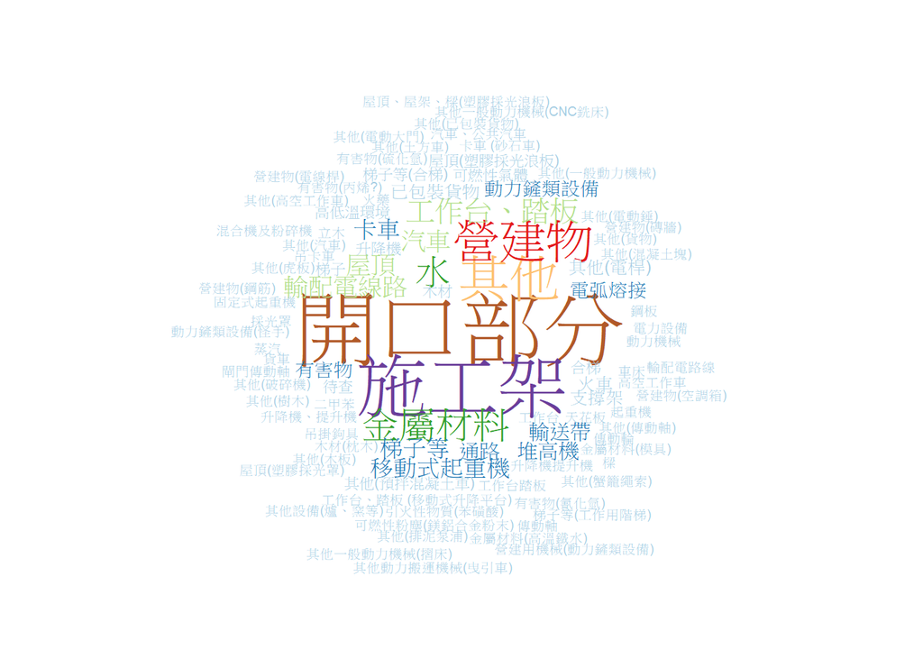

```r
wordcloud(
    words = word_cloud_corpus$媒介物,
    freq = word_cloud_corpus$頻率,
    min.freq = 1,
    #會決定文字雲外觀的參數，要適當調整
    max.words = 100,
    #會決定文字雲外觀的參數，要適當調整
    random.order = FALSE,
    rot.per = 0,
    #要旋轉90度的比例，看個人喜好，設為0也可以
    colors = brewer.pal(12, "Paired"),
)
```

#### 文字雲中的色彩參數可以透過該指令查詢更換，建議colorblind盡量選FALSE的

```r
brewer.pal.info
```

|  | maxcolors | category | colorblind |
| --- | --- | --- | --- |
| BrBG | 11 | div | TRUE |
| PiYG | 11 | div | TRUE |
| PRGn | 11 | div | TRUE |
| PuOr | 11 | div | TRUE |
| RdBu | 11 | div | TRUE |
| RdGy | 11 | div | FALSE |
| RdYlBu | 11 | div | TRUE |
| RdYlGn | 11 | div | FALSE |
| Spectral | 11 | div | FALSE |
| Accent | 8 | qual | FALSE |

[output cut: 25 more lines]

#### 可以看出藍色字體之外的物品都是比較容易造成職業災害的物品

#### 職業災害類型文字雲繪製

```r
word_cloud_corpus <- data.frame(job_disaster_case_compilation$災害類型)
```

#### 變更欄位名稱

```r
colnames(word_cloud_corpus) <- c("災害類型")
```

#### 移除標點符號

```r
word_cloud_corpus$災害類型    <-
    str_remove_all(word_cloud_corpus$災害類型, "[、]")
```

#### 用table()函數幫我統計出頻率，再用sort()函數幫我做降冪排列

```r
word_cloud_corpus <-
    sort(table(word_cloud_corpus$災害類型), decreasing = TRUE)
word_cloud_corpus <- as.data.frame(word_cloud_corpus)
colnames(word_cloud_corpus) <- c("災害類型", "頻率")
```

#### 繪製基本文字雲2

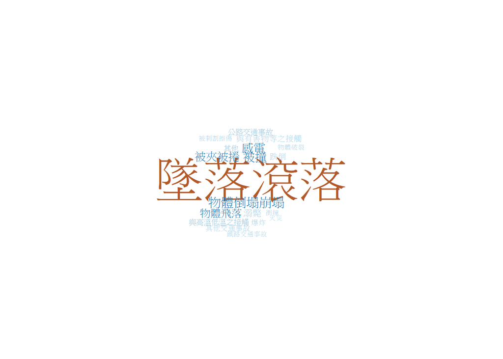

```r
wordcloud(
    words = word_cloud_corpus$災害類型,
    freq = word_cloud_corpus$頻率,
    min.freq = 1,
    #會決定文字雲外觀的參數，要適當調整
    max.words = 100,
    #會決定文字雲外觀的參數，要適當調整
    random.order = FALSE,
    rot.per = 0,
    #要旋轉90度的比例，看個人喜好，設為0也可以
    colors = brewer.pal(12, "Paired"),
)
```

#### 幾乎每個方便好用的函式庫大多都是由其他函式庫組合而成

#### 此類的相依性關係也可以繪製成文字雲

```r
pkgDep("devtools", availPkgs = cranJuly2014)
```

```
##  [1] "devtools"      "httr"          "RCurl"         "memoise"
##  [5] "whisker"       "evaluate"      "digest"        "stringr"
##  [9] "bitops"        "brew"          "Rcpp"          "formatR"
## [13] "highr"         "markdown"      "mime"          "testthat"
## [17] "roxygen2"      "BiocInstaller" "MASS"          "knitr"
## [21] "rstudioapi"
```

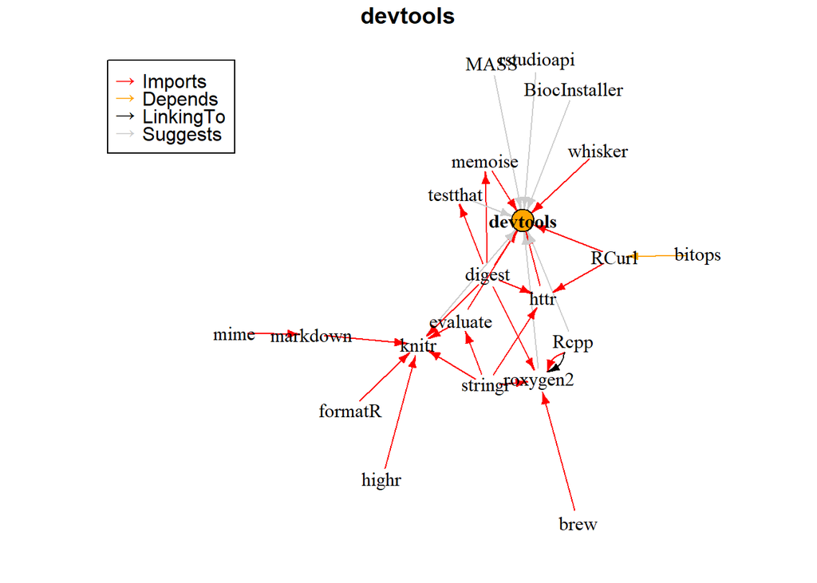

```r
pkg_dep_graph <- makeDepGraph("devtools",
                              enhances = TRUE,
                              availPkgs = cranJuly2014)
plot(pkg_dep_graph,legendPosition = c(-1, 1),
     vertex.size = 10) #vertex.size是主要套件包的圖示尺寸
```

#### 這次使用到的函式庫

```r
used_pkg <- c(
    "NLP",
    "RColorBrewer",
    "colormap",
    "devtools",
    "dplyr",
    "ggplot2",
    "jiebaR",
    "miniCRAN",
    "rmarkdown",
    "rvest",
    "scales",
    "slam",
    "stringr",
    "tidyr",
    "tidyverse",
    "tm",
    "tmcn",
    "treemapify",
    "wesanderson",
    "wordcloud"
)
```

#### 有一些函式庫會沒辦法在cranJuly2014內找到

```r
pkgDep(used_pkg, availPkgs = cranJuly2014)
```

```
##  [1] "NLP"             "RColorBrewer"    "devtools"
##  [4] "dplyr"           "ggplot2"         "scales"
##  [7] "slam"            "stringr"         "tm"
## [10] "wesanderson"     "wordcloud"       "httr"
## [13] "RCurl"           "memoise"         "whisker"
## [16] "evaluate"        "digest"          "bitops"
## [19] "assertthat"      "Rcpp"            "magrittr"
## [22] "Lahman"          "hflights"        "BH"
## [25] "plyr"            "gtable"          "reshape2"
## [28] "proto"           "MASS"            "dichromat"
## [31] "munsell"         "labeling"        "colorspace"
## [34] "brew"            "formatR"         "highr"
## [37] "markdown"        "mime"            "DBI"
## [40] "RSQLite"         "nlme"            "Matrix"
## [43] "lattice"         "SparseM"         "survival"
## [46] "Formula"         "latticeExtra"    "cluster"
## [49] "maps"            "sp"              "foreign"
## [52] "mvtnorm"         "TH.data"         "sandwich"
## [55] "zoo"             "colormap"        "jiebaR"
## [58] "miniCRAN"        "rmarkdown"       "rvest"
## [61] "tidyr"           "tidyverse"       "tmcn"
## [64] "treemapify"      "testthat"        "roxygen2"
## [67] "BiocInstaller"   "knitr"           "rstudioapi"
## [70] "RSQLite.extfuns" "RMySQL"          "MonetDB.R"
## [73] "RPostgreSQL"     "data.table"      "bigrquery"
## [76] "microbenchmark"  "mgcv"            "quantreg"
## [79] "Hmisc"           "mapproj"         "hexbin"
## [82] "maptools"        "multcomp"        "filehash"
## [85] "proxy"           "Rcampdf"         "Rgraphviz"
## [88] "Rpoppler"        "SnowballC"       "XML"
```

#### 原因待查，就先畫圖

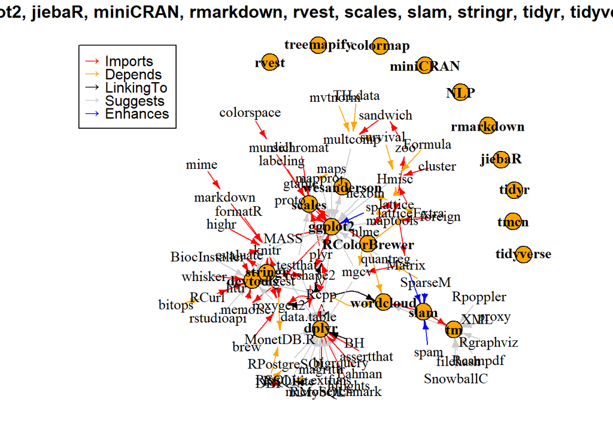

```r
pkg_dep_graph <- makeDepGraph(used_pkg,
                              enhances = TRUE,
                              availPkgs = cranJuly2014)
plot(pkg_dep_graph,
     legendPosition = c(-1, 1),
     vertex.size = 10) #vertex.size是主要套件包的圖示尺寸
```

#### 使用的函式庫越多，就會越像「相依性地獄」

#### 將文字檔案讀入 https://forum.jorsindo.com/portal.php

```r
motor_article_1 <-
    readLines("C:/Users/user/Documents/GitHub/National-Summer-Academy/Week2/小老婆汽機車資訊網語料庫/1.txt")
motor_article_1 <- toString(motor_article_1)

motor_article_2 <-
    readLines("C:/Users/user/Documents/GitHub/National-Summer-Academy/Week2/小老婆汽機車資訊網語料庫/2.txt")
motor_article_2 <- toString(motor_article_2)

motor_article_3 <-
    readLines("C:/Users/user/Documents/GitHub/National-Summer-Academy/Week2/小老婆汽機車資訊網語料庫/3.txt")
motor_article_3 <- toString(motor_article_3)

motor_article_4 <-
    readLines("C:/Users/user/Documents/GitHub/National-Summer-Academy/Week2/小老婆汽機車資訊網語料庫/4.txt")
motor_article_4 <- toString(motor_article_4)

motor_article_5 <-
    readLines("C:/Users/user/Documents/GitHub/National-Summer-Academy/Week2/小老婆汽機車資訊網語料庫/5.txt")
motor_article_5 <- toString(motor_article_5)
```

#### 使用jiebaR斷詞然後轉為文字矩陣

```r
word_segment <- worker()
motor_article_all <- paste(motor_article_1,
                           motor_article_2,
                           motor_article_3,
                           motor_article_4,
                           motor_article_5)

segmented_article <- segment(code = motor_article_all,
                             jiebar = word_segment,
                             mod = "hmm")
print(segmented_article)
```

```
##    [1] "1."           "此版為"       "油品區"       "請針"
##    [5] "對"           "油品"         "發表心"       "得"
##    [9] "跟"           "感想"         "對"           "人"
##   [13] "不"           "對"           "油"           "一律"
##   [17] "視同"         "違反版規"     "2."           "請"
##   [21] "勿"           "濫用給"       "讚"           "機"
##   [25] "制"           "評語"         "部分"         "亦"
##   [29] "適用"         "版規"         "以"           "評語"
##   [33] "攻擊"         "他"           "人"           "酸人"
##   [37] "視同"         "違反版規"     "3."           "如果"
##   [41] "有"           "吵架"         "互相"         "攻擊"
##   [45] "的"           "事情"         "發生"         "管理員會"
##   [49] "贈"           "送"           "警告"         "集滿"
##   [53] "三個"         "可換"         "停權"         "4."
##   [57] "惡意"         "攻擊"         "的"           "網友"
```

[output cut: 804 more lines]

#### 可以看出未經過資料清洗過的文章，斷出來的片段也很糟

#### 進行資料清洗

```r
motor_article_all <- tolower(motor_article_all)
motor_article_all <- str_remove_all(motor_article_all,"[0-9]")
motor_article_all <- str_remove_all(motor_article_all,"[a-z]")
motor_article_all <- gsub("[[:punct:][:blank:]]+", " ", motor_article_all)
```

#### 這樣資料就去除了數字、英文、標點符號、多餘的空格了

#### 再做一次斷詞

```r
segmented_article <- segment(code = motor_article_all,
                             jiebar = word_segment,
                             mod = "hmm")
print(segmented_article)
```

```
##    [1] "此版為"   "油品區"   "請針"     "對"       "油品"     "發表心"
##    [7] "得"       "跟"       "感想"     "對"       "人"       "不"
##   [13] "對"       "油"       "一律"     "視同"     "違反版規" "請"
##   [19] "勿"       "濫用給"   "讚"       "機"       "制"       "評語"
##   [25] "部分"     "亦"       "適用"     "版規"     "以"       "評語"
##   [31] "攻擊"     "他"       "人"       "酸人"     "視同"     "違反版規"
##   [37] "如果"     "有"       "吵架"     "互相"     "攻擊"     "的"
##   [43] "事情"     "發生"     "管理員會" "贈"       "送"       "警告"
##   [49] "集滿"     "三個"     "可換"     "停權"     "惡意"     "攻擊"
##   [55] "的"       "網友"     "即刻"     "砍"       "帳號"     "不"
##   [61] "另"       "通知"     "意圖"     "或"       "是"       "事"
##   [67] "實造成"   "砲"       "文"       "酸文"     "戰文"     "或"
##   [73] "刻意"     "誤導"     "他"       "人"       "之"       "嫌"
##   [79] "疑者"     "均"       "視同"     "違反版規" "發表油品" "心得"
##   [85] "或"       "是"       "詢問"     "油品"     "請"       "盡量"
```

[output cut: 460 more lines]

#### 繪製Document-term matrix

#### 注意這裡要使用的是最原始的語料庫

#### 要處理的重複動作太多就做成function

#### 不知道R語言是否有像Java語言一樣有檢察用的標籤可以讓我知道

#### 自定義的function名稱有沒有Override到既有的function

#### 文字前處理用function

```r
Text_preprocess <- function(article) {
    article <- tolower(article)
    article <- str_remove_all(article, "[0-9]")
    article <- str_remove_all(article, "[a-z]")
    article <- gsub("[[:punct:][:blank:]]+", " ", article)
    return(article)
}

motor_article_1 <- Text_preprocess(motor_article_1)
motor_article_2 <- Text_preprocess(motor_article_2)
motor_article_3 <- Text_preprocess(motor_article_3)
motor_article_4 <- Text_preprocess(motor_article_4)
motor_article_5 <- Text_preprocess(motor_article_5)

motor_article_all <- c(
    motor_article_1,
    motor_article_2,
    motor_article_3,
    motor_article_4,
    motor_article_5
)

segmented_article_corpus <- Corpus(VectorSource(motor_article_all))
tdm <- TermDocumentMatrix(segmented_article_corpus,
                          control = list(wordLengths = c(2, 15)))
inspect(tdm)
```

```
## <<TermDocumentMatrix (terms: 190, documents: 5)>>
## Non-/sparse entries: 193/757
## Sparsity           : 80%
## Maximal term length: 5
## Weighting          : term frequency (tf)
## Sample             :
##             Docs
## Terms        1 2 3 4 5
##   正齒輪     0 0 2 0 0
##   多效齒輪油 0 0 3 0 0
##   例如       1 0 0 0 1
##   相當於     0 0 2 0 0
##   除了       0 0 2 0 0
##   高溫       0 1 0 0 1
##   斜齒輪     0 0 2 0 0
##   添加劑     0 1 1 0 0
##   螺旋齒輪   0 0 2 0 0
##   變速齒輪   0 0 2 0 0
```

#### 該矩陣的Docs是代表輸入的文章數量

#### 由於未做Stop Words(停用詞)的清除

#### 因此連「例如」「除了」「相當於」都被判定為Terms